# Assignment3

Dominique Mashini

19-09-2020

# Assignment 3: Relationships between variables

## Loading packages for the assignment

First, I will load the following libraries for this assignment:

```r
library(ggplot2)
library(tidycensus)
library(tidyverse)
```

```r
library(ggthemes)
```

## Reading and filtering the data

I obtained the data from the 1-year ACS Public Use survey at the person-level in the state of Texas (year 2018). I created a dataframe with the list of all the variables available from the census package. I filtered the variables with the following function:

```r
person_variables_2018 <-
  pums_variables %>%
  distinct(year, survey, var_code, var_label, data_type, level) %>%
  filter(level == "person", year == 2018, survey == "acs1")
```

## Defining, combining, and renaming variables

After browsing through the database person_variables_2018, I defined and renamed my 5 variables of interest:

1. Travel time to work (var code: JWMNP) = Traveltime (continuous)
2. Age (var code: AGEP) = Age (continuous)
3. Educational attainment (var code: SCHL) = Edattain (categorical)
4. Means of Transportation (var code: JWTR) = Meanstransp (categorical)
5. Total person’s income (var code: PINCP) = Income (continuous)

I filtered the data, eliminating the observations with 0 and negative values in the income and travel time variables. I also selected my variables of interest for my categorical variables. I merged some sub-categories of means of transportation, because it is interesting to analyze non-motorized mobility (bicycle or walked), public transportation (bus, streetcar, or subway), and private transportation (car, truck, or van).

```r
vars <- c(
  Traveltime = "JWMNP",
  Age = "AGEP",
  Edattain = "SCHL",
  Meanstransp = "JWTR",
  Income = "PINCP"
)

data <- get_pums(
  variables = vars,
  state = "TX",
  year = 2018,
  survey = "acs1",
  recode = TRUE
) %>%
    filter(Traveltime > 1) %>%
  filter(Income > 0) %>%
  filter(Meanstransp == "01"| Meanstransp == "02"| Meanstransp == "03"|Meanstransp == "04"|Meanstransp == "09"|Meanstransp == "10") %>%
  filter(Edattain == "01"| Edattain == "16" | Edattain == "19" | Edattain == "21" | Edattain == "22" | Edattain == "24") %>%
mutate(Meanstransp = case_when(
    Meanstransp == "01" ~ "Car, truck, or van",
    Meanstransp == "03" | Meanstransp == "04"  | Meanstransp == "02" ~ "Bus, streetcar or subway",
    Meanstransp == "09" | Meanstransp == "10" ~ "Bicycle or walked")) %>%

  mutate(Edattain = case_when(
    Edattain == "01" ~ "1 No schooling completed",
    Edattain == "16" ~ "2 Highschool diploma",
    Edattain == "19" ~ "3 College credit",
    Edattain == "21" ~ "4 Bachelor",
    Edattain == "22" ~ "5 Masters",
    Edattain == "24" ~ "6 Doctorate"))
```

# Relationships between variables

I want to explore the relationship between age, educational attainment, travel time, means of transportation and income on the person level.

## Correlation between Continuous Variables

First, I will test the relationship between my continuous variables (age, travel time and income) by running a correlation test.

```r
correlation1 <- cor.test(data$Age, data$Traveltime)

correlation1
```

```
##
##  Pearson's product-moment correlation
##
## data:  data$Age and data$Traveltime
## t = 11.879, df = 77705, p-value < 2.2e-16
## alternative hypothesis: true correlation is not equal to 0
## 95 percent confidence interval:
##  0.03555448 0.04959106
## sample estimates:
##        cor
## 0.04257487
```

```r
correlation2 <- cor.test(data$Age, data$Income)

correlation2
```

```
##
##  Pearson's product-moment correlation
##
## data:  data$Age and data$Income
## t = 70.072, df = 77705, p-value < 2.2e-16
## alternative hypothesis: true correlation is not equal to 0
## 95 percent confidence interval:
##  0.2371646 0.2503909
## sample estimates:
##       cor
## 0.2437891
```

```r
correlation3 <- cor.test(data$Traveltime, data$Income)

correlation3
```

```
##
##  Pearson's product-moment correlation
##
## data:  data$Traveltime and data$Income
## t = 18.888, df = 77705, p-value < 2.2e-16
## alternative hypothesis: true correlation is not equal to 0
## 95 percent confidence interval:
##  0.06060093 0.07459874
## sample estimates:
##        cor
## 0.06760316
```

Correlation analysis based on Pearson’s r and p-values:

In my three correlation analysis I see a weak, but statistically significant, positive relationship at a 95% confidence level. The stronger correlation is seen between age and income (cor =0.24). To visualize these relationships, I will use scatter plot graphs:

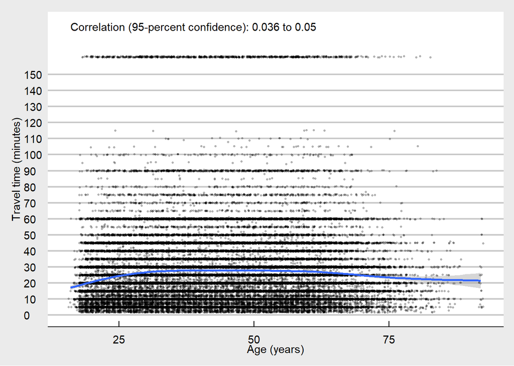

```r
ggplot(data, aes(x = Age, y = Traveltime)) +
    geom_point(size = 0.5, alpha = 0.25, position = "jitter") +
    geom_smooth() +
    theme_economist_white() +
    scale_x_continuous(name = "Age (years)") +
    scale_y_continuous(name = "Travel time (minutes)",
                      breaks = seq(0, 150, by = 10),
                      labels = paste("",
                                  prettyNum(seq(0, 150, by = 10),
                                            big.mark = ","))) +
      annotate(geom = "text", x = 16, y = 180,
           label = paste("Correlation (95-percent confidence):",
                         prettyNum(correlation1$conf.int[1], digits = 2),
                         "to",
                         prettyNum(correlation1$conf.int[2], digits = 2)),
           hjust = 0)
```

Looking at the scatter plot graph, it is more evident that the correlation is weaker and slightly negative over 65 years.

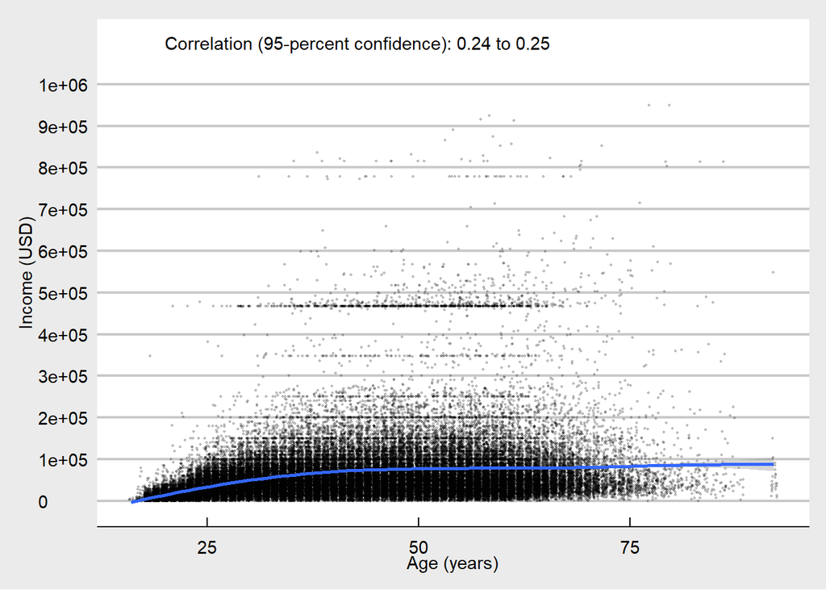

```r
ggplot(data, aes(x = Age, y = Income)) +
    geom_point(size = 0.4, alpha = 0.2, position = "jitter") +
    geom_smooth() +
    theme_economist_white() +
    scale_x_continuous(name = "Age (years)") +
    scale_y_continuous(name = "Income (USD)",
                      breaks = seq(0, 1000000, by = 100000),
                      labels = paste("",
                                  prettyNum(seq(0, 1000000, by = 100000),
                                            big.mark = ","))) +
          annotate(geom = "text", x = 20, y = 1100000,
           label = paste("Correlation (95-percent confidence):",
                         prettyNum(correlation2$conf.int[1], digits = 2),
                         "to",
                         prettyNum(correlation2$conf.int[2], digits = 2)),
           hjust = 0)
```

I can see a stronger, positive correlation between age and income.

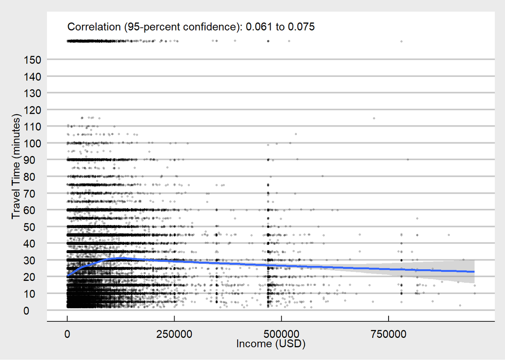

```r
ggplot(data, aes(x = Income, y = Traveltime)) +
    geom_point(size = 0.5, alpha = 0.2, position = "jitter") +
    geom_smooth() +
    theme_economist_white() +
    scale_x_continuous(name = "Income (USD)") +
    scale_y_continuous(name = "Travel Time (minutes)",
                      breaks = seq(0, 150, by = 10),
                      labels = paste("",
                                  prettyNum(seq(0, 150, by = 10),
                                            big.mark = ","))) +
       annotate(geom = "text", x = 0, y = 170,
           label = paste("Correlation (95-percent confidence):",
                         prettyNum(correlation3$conf.int[1], digits = 2),
                         "to",
                         prettyNum(correlation3$conf.int[2], digits = 2)),
           hjust = 0)
```

There is an interesting visualization of the correlation between income and travel time. While positive, there are fewer high-income people who travel more than 150 minutes.

## Relationship between Categorical Variables

I will use the Chi-square test of association for determining whether there is a statistically significant association between my two categorical variables.

```r
chi_sq <- chisq.test(data$Edattain, data$Meanstransp)
chi_sq
```

```
##
##  Pearson's Chi-squared test
##
## data:  data$Edattain and data$Meanstransp
## X-squared = 137, df = 10, p-value < 2.2e-16
```

```r
knitr::kable(chi_sq$observed)
```

|  | Bicycle or walked | Bus, streetcar or subway | Car, truck, or van |
| --- | --- | --- | --- |
| 1 No schooling completed | 35 | 36 | 1518 |
| 2 Highschool diploma | 451 | 305 | 21332 |
| 3 College credit | 463 | 205 | 17199 |
| 4 Bachelor | 337 | 229 | 24087 |
| 5 Masters | 177 | 146 | 9577 |
| 6 Doctorate | 46 | 24 | 1540 |

```r
knitr::kable(chi_sq$expected)
```

|  | Bicycle or walked | Bus, streetcar or subway | Car, truck, or van |
| --- | --- | --- | --- |
| 1 No schooling completed | 30.85695 | 19.32393 | 1538.819 |
| 2 Highschool diploma | 428.92908 | 268.61364 | 21390.457 |
| 3 College credit | 346.96106 | 217.28178 | 17302.757 |
| 4 Bachelor | 478.73907 | 299.80677 | 23874.454 |
| 5 Masters | 192.24909 | 120.39456 | 9587.356 |
| 6 Doctorate | 31.26475 | 19.57932 | 1559.156 |

```r
C_diff <- chi_sq$observed - chi_sq$expected

C_diff_data <- as.data.frame(C_diff)
C_diff_data
```

```
##               data.Edattain         data.Meanstransp        Freq
## 1  1 No schooling completed        Bicycle or walked    4.143050
## 2      2 Highschool diploma        Bicycle or walked   22.070920
## 3          3 College credit        Bicycle or walked  116.038941
## 4                4 Bachelor        Bicycle or walked -141.739071
## 5                 5 Masters        Bicycle or walked  -15.249090
## 6               6 Doctorate        Bicycle or walked   14.735249
## 7  1 No schooling completed Bus, streetcar or subway   16.676065
## 8      2 Highschool diploma Bus, streetcar or subway   36.386362
## 9          3 College credit Bus, streetcar or subway  -12.281776
## 10               4 Bachelor Bus, streetcar or subway  -70.806774
## 11                5 Masters Bus, streetcar or subway   25.605441
## 12              6 Doctorate Bus, streetcar or subway    4.420683
## 13 1 No schooling completed       Car, truck, or van  -20.819115
## 14     2 Highschool diploma       Car, truck, or van  -58.457282
## 15         3 College credit       Car, truck, or van -103.757165
## 16               4 Bachelor       Car, truck, or van  212.545845
## 17                5 Masters       Car, truck, or van  -10.356351
## 18              6 Doctorate       Car, truck, or van  -19.155932
```

I can assume there is a statistically significant relationship at a 95% confidence interval between educational attainment and means of transportation because the p-value is below 0.05.

In the tables I see some values that have a particularly low frequency, such as no schooling completed with non-motorized mobilization and doctorate with bus, streetcar or subway.

## Relationships between Educational Attainment and Continuous Variables

For the relationship between my categorical and continuous variables, I will use the anova test:

```r
anova <- aov(data$Age ~ data$Edattain)

summary(anova)
```

```
##                  Df   Sum Sq Mean Sq F value Pr(>F)
## data$Edattain     5   304640   60928   295.5 <2e-16 ***
## Residuals     77701 16023364     206
## ---
## Signif. codes:  0 '***' 0.001 '**' 0.01 '*' 0.05 '.' 0.1 ' ' 1
```

```r
anova <- aov(data$Traveltime ~ data$Edattain)

summary(anova)
```

```
##                  Df   Sum Sq Mean Sq F value   Pr(>F)
## data$Edattain     5    13114  2622.7   5.471 4.87e-05 ***
## Residuals     77701 37246504   479.4
## ---
## Signif. codes:  0 '***' 0.001 '**' 0.01 '*' 0.05 '.' 0.1 ' ' 1
```

```r
anova <- aov(data$Income ~ data$Edattain)

summary(anova)
```

```
##                  Df    Sum Sq   Mean Sq F value Pr(>F)
## data$Edattain     5 4.549e+13 9.099e+12    1867 <2e-16 ***
## Residuals     77701 3.787e+14 4.874e+09
## ---
## Signif. codes:  0 '***' 0.001 '**' 0.01 '*' 0.05 '.' 0.1 ' ' 1
```

Difference Check:

```r
differences <- TukeyHSD(anova)
differences
```

```
##   Tukey multiple comparisons of means
##     95% family-wise confidence level
##
## Fit: aov(formula = data$Income ~ data$Edattain)
##
## $`data$Edattain`
##                                                    diff        lwr        upr
## 2 Highschool diploma-1 No schooling completed  4807.854  -359.3014   9975.009
## 3 College credit-1 No schooling completed     11323.454  6115.4977  16531.410
## 4 Bachelor-1 No schooling completed           45910.327 40761.2435  51059.410
## 5 Masters-1 No schooling completed            63085.346 57708.9671  68461.725
## 6 Doctorate-1 No schooling completed          95456.116 88421.1741 102491.059
## 3 College credit-2 Highschool diploma          6515.600  4513.8501   8517.350
## 4 Bachelor-2 Highschool diploma               41102.473 39259.3083  42945.638
## 5 Masters-2 Highschool diploma                58277.492 55871.3239  60683.661
```

[output cut: 23 more lines]

There exists a significant association between educational attainment and age, income and travel time. On a more in-depth review of income and educational attainment, a positive difference and significant association appear, except between highschool diploma and no schooling completed (p adj = 0.085).

I decided to display the relationship between educational attainment and income using a box-plot. As my categorical variable is ordinal, I ordered the educational attainment categories for a better visualization of the relationship:

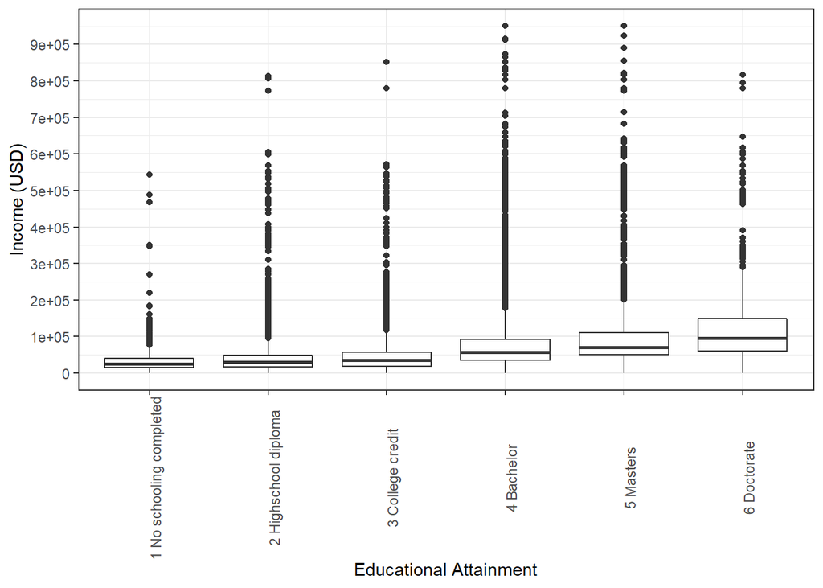

```r
ggplot(data, aes(x = Edattain, y = Income)) +
  geom_boxplot() +
  theme_bw() +
  theme(axis.text.x = element_text(angle = 90)) +
  scale_x_discrete(name = "Educational Attainment") +
  scale_y_continuous(name = "Income (USD)",
                     breaks = seq(0, 1000000, by = 100000),
                     labels = paste(prettyNum(seq(0, 1000000, by = 100000),
                                              big.mark = ",")))
```

## Relationships between Means of Transportation and Continuous Variables

For the relationship between my categorical and continuous variables, I use the anova test:

```r
anova <- aov(data$Age ~ data$Meanstransp)

summary(anova)
```

```
##                     Df   Sum Sq Mean Sq F value Pr(>F)
## data$Meanstransp     2   102329   51165     245 <2e-16 ***
## Residuals        77704 16225675     209
## ---
## Signif. codes:  0 '***' 0.001 '**' 0.01 '*' 0.05 '.' 0.1 ' ' 1
```

```r
anova <- aov(data$Traveltime ~ data$Meanstransp)

summary(anova)
```

```
##                     Df   Sum Sq Mean Sq F value Pr(>F)
## data$Meanstransp     2   649856  324928   689.7 <2e-16 ***
## Residuals        77704 36609761     471
## ---
## Signif. codes:  0 '***' 0.001 '**' 0.01 '*' 0.05 '.' 0.1 ' ' 1
```

```r
anova <- aov(data$Income ~ data$Meanstransp)

summary(anova)
```

```
##                     Df    Sum Sq   Mean Sq F value Pr(>F)
## data$Meanstransp     2 1.087e+12 5.434e+11    99.8 <2e-16 ***
## Residuals        77704 4.231e+14 5.445e+09
## ---
## Signif. codes:  0 '***' 0.001 '**' 0.01 '*' 0.05 '.' 0.1 ' ' 1
```

```r
differences <- TukeyHSD(anova)
differences
```

```
##   Tukey multiple comparisons of means
##     95% family-wise confidence level
##
## Fit: aov(formula = data$Income ~ data$Meanstransp)
##
## $`data$Meanstransp`
##                                                 diff       lwr      upr
## Bus, streetcar or subway-Bicycle or walked  12579.44  5405.194 19753.69
## Car, truck, or van-Bicycle or walked        25304.42 20808.006 29800.83
## Car, truck, or van-Bus, streetcar or subway 12724.98  7063.972 18385.98
##                                                 p adj
## Bus, streetcar or subway-Bicycle or walked  0.0001174
## Car, truck, or van-Bicycle or walked        0.0000000
## Car, truck, or van-Bus, streetcar or subway 0.0000004
```

There exists a significant relationship between means of transportation and all the continuous variables at a 95% confidence level, with all p-values under the 0.05 threshold. In the difference check between income and means of transportation, there is a lower incidence of income between the variables ‘bus, streetcar or subway’ and ‘bicycle or walked’.

I decided to display the relationship between travel time and means of transportation using a box-plot:

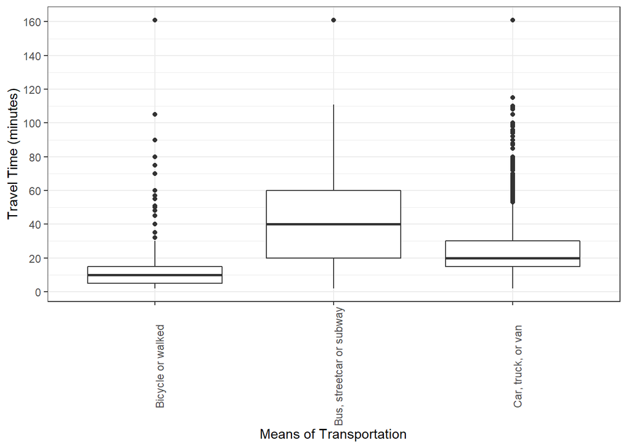

```r
ggplot(data, aes(x = Meanstransp, y = Traveltime)) +
  geom_boxplot() +
  theme_bw() +
  theme(axis.text.x = element_text(angle = 90)) +
  scale_x_discrete(name = "Means of Transportation") +
  scale_y_continuous(name = "Travel Time (minutes)",
                     breaks = seq(0, 200, by = 20),
                     labels = paste(prettyNum(seq(0, 200, by = 20),
                                              big.mark = ",")))
```

As expected, the travel time is longer and more varied in the ‘bus, streetcar, or subway’ variable, followed by ‘car, truck, or van’. The time traveled by bicycle or walked is less.

## Relationship between Means of Transportation (Motorized and Non-motorized) and Age

To further my analysis, I combined the categories of means of transportation into motorized and non-motorized, in order to test them with age through a two-sample t-test.

```r
data1 <- data %>%
    mutate(
        motor = case_when(
            Meanstransp == "Car, truck, or van" |  Meanstransp == "Bus, streetcar or subway" ~ "motor",
            Meanstransp == "Bicycle or walked"  ~ "no motor"
        ))

differences1 <- t.test(data1$Age ~ data1$motor == "motor")
differences1
```

```
##
##  Welch Two Sample t-test
##
## data:  data1$Age by data1$motor == "motor"
## t = -20.257, df = 1561.9, p-value < 2.2e-16
## alternative hypothesis: true difference in means is not equal to 0
## 95 percent confidence interval:
##  -8.805661 -7.250908
## sample estimates:
## mean in group FALSE  mean in group TRUE
##            34.72962            42.75791
```

There is a significant relationship (negative, seen in the 95 percent confidence interval) found between age and means of transportation (motorized and non-motorized); the youngest use more non-motorized transport.